# DATA606_Meetup Presentation_6.11_Study_abroad

Matheesha Thambeliyagodage

May 10, 2017

### 6.11 Study abroad.

A survey on 1,509 high school seniors who took the SAT and who completed an optional web survey between April 25 and April 30, 2007 shows that 55% of high school seniors are fairly certain that they will participate in a study abroad program in college

**(a) Is this sample a representative sample from the population of all high school seniors in the US? Explain your reasoning.**  
- Here Sample observations are independent. The sample doesnt represententire high school population. Not all high schoolers take the SAT; some take the ACT instead. It would be a good sample representation of all US high school seniors who took the SAT.

```r
n <-1509
p <- 0.55
success <- n*p
failure <- n*(1-p)
success
```

```
## [1] 829.95
```

```r
failure
```

```
## [1] 679.05
```

$SE=\sqrt{\frac{p*(1-p)}{n}}$

```r
se <-  sqrt((p*(1-p))/n)  ## Standard Error
z <- qnorm(.90)  ## Quantile Function - inverse of pnorm
CI.UPPER <- p+z*se
CI.LOWER<- p-z*se
se
```

```
## [1] 0.01280687
```

```r
z
```

```
## [1] 1.281552
```

```r
CI.UPPER
```

```
## [1] 0.5664127
```

```r
CI.LOWER
```

```
## [1] 0.5335873
```

```r
CI <- c(CI.LOWER, CI.UPPER)
CI
```

```
## [1] 0.5335873 0.5664127
```

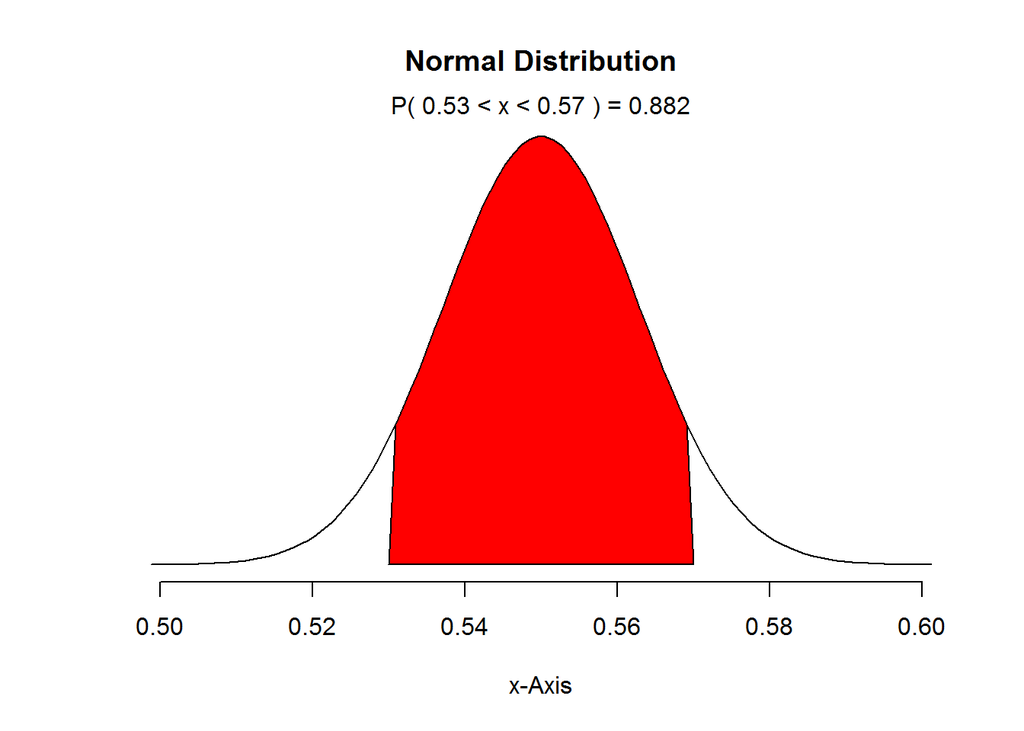

```r
normalPlot(p,se,bounds = c(0.53,0.57),tails=FALSE)
```

**(d) Based on this interval, would it be appropriate to claim that the majority of high school seniors are fairly certain that they will participate in a study abroad program in college?**  
- Possible toclaim that the majority of HS seniors are fairly certain that they would participate in a study above program. What we found is the interval is over 50% (majority).